# SNP_info_nNILs

Jim Holland

2024-06-17

# Get HapMap Data on founders

Read in the founder HapMap SNPs in v3

```r
founderVCF = read.vcfR(paste0(base.path, "Data/nNIL_founders_consistent_gbsSNPs_v3.vcf.gz"), verbose = FALSE )
```

Get the info in v3 on each SNP, get the original ordering of SNPs in vcf

```r
founder_meta = founderVCF@fix
founder_meta = cbind(founder_meta, ord = 1:nrow(founder_meta))
```

Get the set of SNPs overlapping between nNIL gbs markers and HapMap3 markers with consistent REF/ALT alleles (identified in Step 4)

```r
consistentSNPs = read.csv(paste0(base.path, "Output/nNIL_gbs_SNPs_congruent_w_HapMap_v3v4v5coords_info.csv"))
```

Match the v3 position info with the v4 position info

```r
founder_meta_v4 = merge(founder_meta[,c("CHROM", "POS", "ord")], consistentSNPs, by.x = c("CHROM", "POS"), by.y = c("chrV3", "endV3")) %>%
  mutate(ord = as.numeric(ord)) %>%
  arrange(ord)
```

Verify the sorted V3 order matches the order of SNPs in founder matrix

```r
all(founder_meta_v4$POS == founder_meta[,"POS"])
```

```
## [1] TRUE
```

Get the founder calls

```r
founder_calls =extract.gt(founderVCF, return.alleles = T)
founder_calls[founder_calls == "."] = NA
```

We verified above that the sorting of SNP names in founder_meta_v4 matches the founder VCF, so we can use the V4 SNP names to replace the V3 based row names.

```r
row.names(founder_calls) = founder_meta_v4$nameV4
colnames(founder_calls) = sub("282set_", "", colnames(founder_calls))
```

Convert the biallelic calls in founder_calls to single character IUPAC values, this is format used by the gbs_snp_v4 data frame.

```r
biallelic_to_IUPAC = function(x){
  if (is.na(x)) {return(x)}
  if (x == "A/A") {return("A")}
  if (x == "C/C") {return("C")}
  if (x == "G/G") {return("G")}
  if (x == "T/T") {return("T")}
  if (x == "A/C" | x == "C/A") {return("M")}
  if (x == "A/G" | x == "G/A") {return("R")}
  if (x == "A/T" | x == "T/A") {return("W")}
  if (x == "C/G" | x == "G/C") {return("S")}
  if (x == "C/T" | x == "T/C") {return("Y")}
  if (x == "G/T" | x == "T/G") {return("K")}
  return(NA) #in case no match
}
```

```r
founder_calls_iupac = apply(founder_calls, 1:2, biallelic_to_IUPAC)
```

# nNIL GBS SNP calls and introgression calls

Get nNIL GBS SNPs in original V4 positions uplifted to V3 This is a subset after filtering to < 20% missing data in the vcf.

```r
gbs_v3 = read.table(paste0(base.path, "Data/nNIL_gbs_snps_converted_V3.bed"))
names(gbs_v3) = c("chrV3", "startV3", "endV3", "nameV4", "score", "strand")
gbs_v3 = gbs_v3 %>% separate(nameV4, into = c("chrV4", "posV4"), sep = "_", remove = F) %>%
  mutate(chrV4 = as.integer(sub("S", "", chrV4)))%>%
  select(-score, -strand)
```

Check GBS nNIL SNP info directly from hapmap meta data column alleles. Assuming first allele is reference

```r
gbs_snp_v4 =
read.table(paste0(base.path,"Data/raw_snps_bgi_id.hmp.txt"), comment.char = "", header = T)
colnames(gbs_snp_v4)[1:4] = c("nameV4", "alleles", "chrV4", "posV4")
```

Now subset the GBS SNP calls on nNIL lines to the same set of SNPs. Make sure missing values of N are set to NA. Also a few rare values need to be set to missing

```r
gbs_snp_v4_consistent = gbs_snp_v4[gbs_snp_v4$nameV4 %in% row.names(founder_calls),]
gbs_snp_v4_consistent[gbs_snp_v4_consistent == "-"] = NA
gbs_snp_v4_consistent[gbs_snp_v4_consistent == "N"] = NA
gbs_snp_v4_consistent[gbs_snp_v4_consistent == "O"] = NA
```

change NIL line names from BGI codes to standard NIL line names

```r
name_translator = read.table(paste0(base.path, "Data/bgi_nil_id.txt"), sep = "\t", header = T, fileEncoding = "latin1")
name_translator = name_translator %>%
  mutate(bgi_id = gsub("-", ".", bgi_id),
    nil_id = sub("B73.NIL", "B73 NIL", nil_id))
name_translator_vec = name_translator$nil_id
names(name_translator_vec) = name_translator$bgi_id
colnames(gbs_snp_v4_consistent)[12:ncol(gbs_snp_v4_consistent)] = name_translator_vec[colnames(gbs_snp_v4_consistent)[12:ncol(gbs_snp_v4_consistent)]]
```

Get the introgression calls on the nNILs

```r
intros = read.csv(paste0(base.path, "Output/Individual_Introgressions_gbs.csv"))
```

Keep only NILs whose line names match the gbs line names

```r
intros_sub = intros |>
  filter(Line %in% colnames(gbs_snp_v4_consistent))
```

Get the introgression calls

```r
intro.calls = fread("C:/Users/jholland/Box/nNIL genotype data Jim and Tao/nNIL_data_supplement/File_S18.nNIL_gbs_HMM_introgressionCalls_full_set.csv")
```

Get the list of nNILs from introgression calls

```r
allLines = unlist(intro.calls[,1])
```

# Correct SNP ordering and formats

Finally, get the order of SNPs identical between founder_calls_iupac and gbs_snp_v4_consistent. Since the founder gbs and the nNIL gbs were aligned to different reference genomes, their ordering may vary and we need to make them identical

```r
all(rownames(founder_calls_iupac) == gbs_snp_v4_consistent$nameV4)
```

```
## [1] FALSE
```

Resort the founder call SNPs to match nNILs. Need to parse the names into chrom and position to do this, then sort by NUMERIC chromosome and position

```r
founder_call_snps = strsplit(rownames(founder_calls_iupac), "_")
founder_call_snps = as.data.frame(do.call(rbind, founder_call_snps))
colnames(founder_call_snps) = c("chrV4", "posV4")
founder_call_snps$chrV4 = sub("S", "", founder_call_snps$chrV4)
founder_call_snps$nameV4 = rownames(founder_calls_iupac)
founder_calls_iupac = cbind(founder_call_snps, founder_calls_iupac)
founder_calls_iupac = as.data.frame(founder_calls_iupac) %>%
  mutate(chrV4 = as.numeric(chrV4),
         posV4 = as.numeric(posV4)) %>%
  arrange(chrV4, posV4)
```

Check that the new sorting matches the nNIL gbs marker order exactly

```r
all(founder_calls_iupac$nameV4 == gbs_snp_v4_consistent$nameV4)
```

```
## [1] TRUE
```

Yay!!

# Compare SNP calls within each introgression block in each nNIL to founders

```r
compare_SNPs_in_intros_nohets = function(x){
  #x is one row of intros_sub data frame, becomes a character vector here
  #extract the column of chip SNP calls for the current NIL along with metadata cols
  line_SNPcalls = gbs_snp_v4_consistent[,c('nameV4','chrV4', 'posV4', x['Line'])]
  #extract the markers defining the current introgression block
  selectMarkers = line_SNPcalls |>
    filter((chrV4 == as.numeric(x['chr']))  & (posV4 >= as.numeric(x['pos_leftflank'])) & (posV4 <= as.numeric(x['pos_rightflank'])))
  #subset the current NILs SNP calls to only the current introgression
  line_SNPcalls_in_intro = unlist(selectMarkers[x['Line']])

  #subset the founder SNP calls to the same set of markers, dropping cols 1 - 3 of meta-data
  match_founders = founder_calls_iupac[selectMarkers$nameV4,-c(1:3)]
  #compute the match percentage, ignoring hets/NAs
  compare = apply(match_founders, 2, FUN = function(y) {sum(y == line_SNPcalls_in_intro, na.rm = T)/sum(!is.na(y) & !is.na(line_SNPcalls_in_intro))})
  #also compute the number of SNPs NOT missing (not hets)
  N.homoz = sum(!is.na(line_SNPcalls_in_intro))
  return(list(compare, nrow(selectMarkers), N.homoz))
}
```

Apply the function to every row of intros_sub data.frame

```r
#extract all of the nested first components of the list components:
comp.list = apply(intros_sub,1,compare_SNPs_in_intros_nohets)
nNIL_compare = lapply(comp.list, function(x) x[[1]])
nNIL_compare = do.call(rbind, nNIL_compare)
colnames(nNIL_compare) = c(colnames(founder_calls_iupac)[-c(1:3)])
#extract all of the nested 2nd components of the list components:
n.SNPs = lapply(comp.list, function(x) x[[2]])
n.SNPs = do.call(c, n.SNPs)
#extract all of the nested 3rd components of the list components:
N.homoz = lapply(comp.list, function(x) x[[3]])
N.homoz = do.call(c, N.homoz)
intros.info = cbind(intros_sub, nNIL_compare)
intros.info$N.SNPs = n.SNPs
intros.info$N.homoz = N.homoz
intros.info$perc.homoz = intros.info$N.homoz/intros.info$N.SNPs
```

Find best match over 0.8 for each introgression

```r
best.matches = apply(nNIL_compare, 1, function(x) colnames(nNIL_compare)[which.max(x)])
matches.80 = apply(nNIL_compare, 1, function(x) x[which.max(x)] > 0.8)
#matches with missing values return logical(0), convert these to FALSE
matches.80 = unlist(lapply(matches.80, function(x) ifelse(length(x) == 0, F, x)))
best.matches[!matches.80]= NA
intros.info$best.matches = unlist(best.matches)
```

Parse the pedigree donor from the line name, fix up donor names

```r
intros.info = intros.info |>
  separate_wider_delim(cols = Line, delim = "/", names = c("ped.donor", "suffix"), cols_remove = F) |>
  mutate(ped.donor = ifelse(ped.donor == "MO17", "Mo17", ped.donor),
         ped.donor = ifelse(ped.donor == "KI3", "Ki3", ped.donor),
         best.matches = ifelse(best.matches == "KI3", "Ki3", best.matches),
         ped.match = ped.donor==best.matches,
         intro.size.Mbp = intro.size/1000000)
```

Check that all ped.donor names match hapmap names

```r
unique(intros.info$ped.donor)[!unique(intros.info$ped.donor) %in% intros.info$best.matches]
```

```
## character(0)
```

```r
unique(intros.info$best.matches)[!unique(intros.info$best.matches) %in% intros.info$ped.donor]
```

```
## [1] NA    "B73"
```

How many total introgressions were detected?

```r
nrow(intros.info)
```

```
## [1] 2969
```

How many unique nNILs were introgressions detected in?

```r
length(unique(intros.info$Line))
```

```
## [1] 880
```

# Visualize distribution of introgression sizes before any filtering

Summary of introgression sizes for all unfiltered introgressions

```r
summary(intros.info$intro.size)
```

```
##      Min.   1st Qu.    Median      Mean   3rd Qu.      Max.
##        20   1171008   4498054  17018867  14504960 203569885
```

What proportion of introgressions are < 10kb in size?

```r
intros.info |>
  summarize(prop.small.intros = sum(intro.size < 10000)/n())
```

```
## # A tibble: 1 × 1
##   prop.small.intros
##               <dbl>
## 1            0.0482
```

```r
intros.info |>
  filter(intro.size < 5000) |>
  arrange(chr, pos_leftflank)
```

```
## # A tibble: 114 × 42
##      chr ped.donor suffix   Line  pos_leftflank pos_start pos_end pos_rightflank
##    <int> <chr>     <chr>    <chr>         <int>     <int>   <int>          <int>
##  1     1 Tx303     B73 NIL… Tx30…       8575205   8575209  8.58e6        8576883
##  2     1 Tx303     B73 NIL… Tx30…       8575205   8575209  8.58e6        8576883
##  3     1 Oh43      B73 NIL… Oh43…      13055693  13062465  1.31e7       13063972
##  4     1 CML103    B73 NIL… CML1…      16415903  16415904  1.64e7       16415944
##  5     1 Mo18W     B73 NIL… Mo18…      17312279  17312299  1.73e7       17314954
##  6     1 NC358     B73 NIL… NC35…      17312279  17312299  1.73e7       17314954
##  7     1 Oh43      B73 NIL… Oh43…      25718762  25719227  2.57e7       25719241
##  8     1 CML228    B73 NIL… CML2…      32069756  32069831  3.21e7       32072081
##  9     1 Tx303     B73 NIL… Tx30…      45720645  45721049  4.57e7       45725662
## 10     1 CML69     B73 NIL… CML6…      93797620  93797621  9.38e7       93798384
## # ℹ 104 more rows
## # ℹ 34 more variables: marker_left_flank <chr>, marker_start <chr>,
## #   marker_end <chr>, marker_right_flank <chr>, chrom.size <int>,
## #   intro_start <dbl>, intro_end <dbl>, intro.size <dbl>, intro.prop.chr <dbl>,
## #   B73 <dbl>, CML103 <dbl>, CML228 <dbl>, CML247 <dbl>, CML277 <dbl>,
## #   CML322 <dbl>, CML333 <dbl>, CML52 <dbl>, CML69 <dbl>, KI3 <dbl>,
## #   Ki11 <dbl>, M162W <dbl>, Mo17 <dbl>, Mo18W <dbl>, NC350 <dbl>, …
```

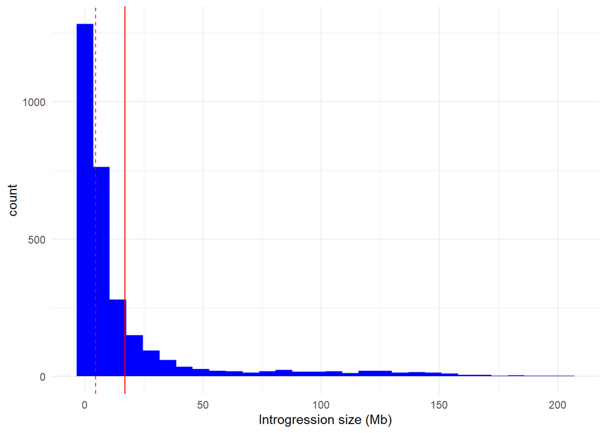

```r
ggplot(intros.info, aes(x = intro.size.Mbp)) +
  geom_histogram(fill = 'blue') +
  xlab('Introgression size (Mb)') +
  geom_vline(xintercept = mean(intros.info$intro.size.Mbp), color = "red") +
  geom_vline(xintercept = median(intros.info$intro.size.Mbp), color = "red", linetype = 2) +
  theme_minimal()
```

```r
ggsave(filename = "C:/Users/jholland/Box/nNIL genotype data Jim and Tao/Output/Histogram of Introgression Sizes No Filtering.tiff", dpi = 300, width = 10, height = 8, units = "in", bg = "white")
```

# Visualize introgression size distributions as proportion of total chromosome lengths before filtering

Summary for all introgressions without filtering

```r
summary(intros.info$intro.prop.chr)
```

```
##      Min.   1st Qu.    Median      Mean   3rd Qu.      Max.
## 0.0000001 0.0055100 0.0212658 0.0810901 0.0642727 0.9173837
```

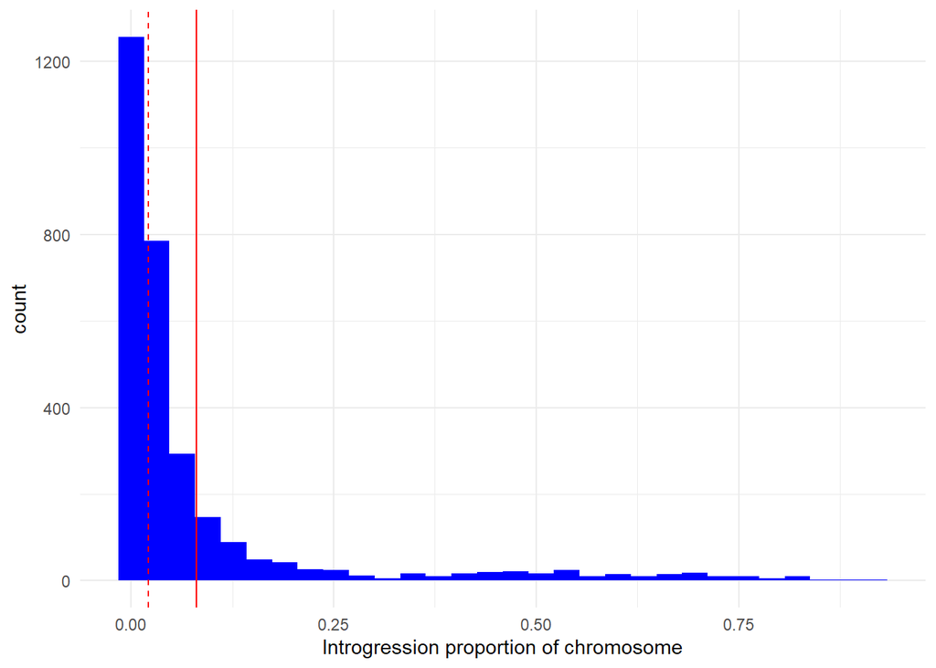

```r
ggplot(intros.info, aes(x = intro.prop.chr)) +
  geom_histogram(fill = 'blue') +
  geom_vline(xintercept = mean(intros.info$intro.prop.chr), color = "red") +
  geom_vline(xintercept = median(intros.info$intro.prop.chr), color = "red", linetype = 2) +
  xlab('Introgression proportion of chromosome') +
  theme_minimal()
```

```r
ggsave(filename = "C:/Users/jholland/Box/nNIL genotype data Jim and Tao/Output/Histogram of Introgression Proportions of Chromosomes No Filtering.tiff", dpi = 300, width = 10, height = 8, units = "in", bg = "white")
```

# visualize the proportion of genome introgressed into each nNIL

Summarize over Lines, get the amount of sequence and proportion of genome introgressed for each line:

```r
V4.total.size = 2120000000
line.summary = intros.info %>%
  group_by(Line) %>%
  summarize(N.blocks.unfiltered = n(),
            Total.Intro.Sizes.Unfiltered = sum(intro.size),
            Total.Intro.Prop.Unfiltered = Total.Intro.Sizes.Unfiltered/V4.total.size)

summary(line.summary$Total.Intro.Prop.Unfiltered)
```

```
##     Min.  1st Qu.   Median     Mean  3rd Qu.     Max.
## 0.000002 0.005502 0.013056 0.027085 0.037580 0.624212
```

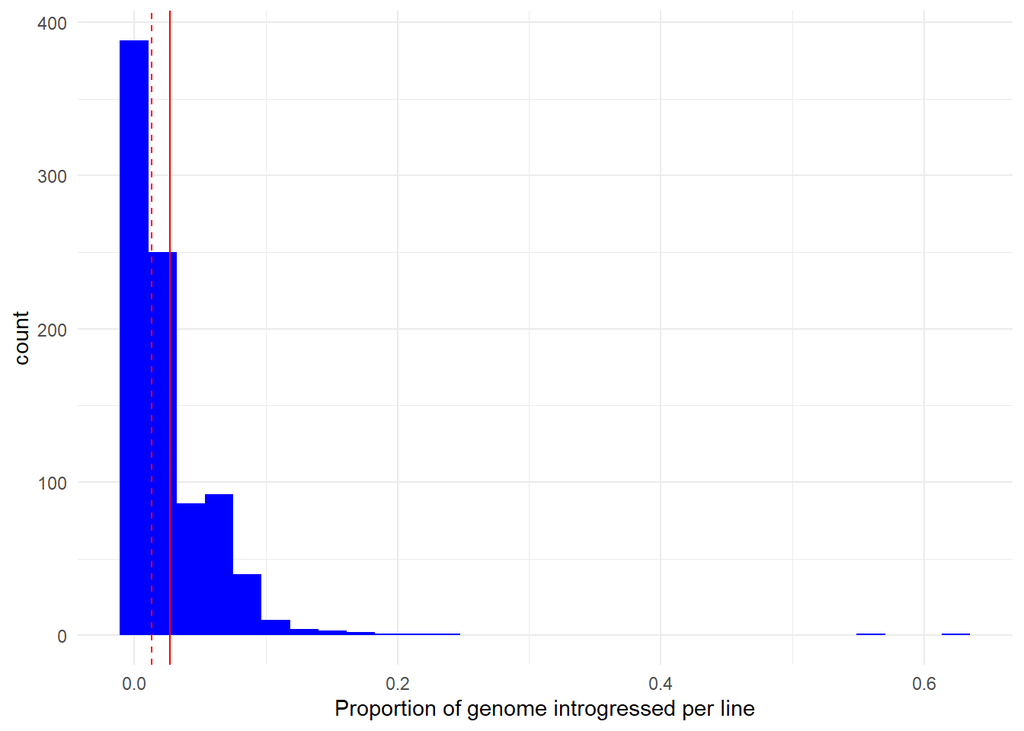

```r
line.summary %>%
  ggplot(aes(x = Total.Intro.Prop.Unfiltered)) +
  geom_histogram(fill = 'blue') +
  xlab("Proportion of genome introgressed per line") +
  geom_vline(xintercept = mean(unlist(line.summary$Total.Intro.Prop.Unfiltered)), color = "red") +
  geom_vline(xintercept = median(unlist(line.summary$Total.Intro.Prop.Unfiltered)), color = "red", linetype = 2) +
  theme_minimal()
```

# Inspect match results and filter for high quality matches

Diagnose the matches to B73. Hypothesis is that these are either small introgression blocks or highly heterozygous blocks:

```r
intros.info |>
  mutate(GROUP = case_when(
    is.na(best.matches) ~ "NA",
    best.matches == "B73" ~ "B73",
    best.matches == ped.donor ~ "CORRECT",
    best.matches != ped.donor ~ "WRONG"
  )) |>
  group_by(GROUP) |>
  summarise(N.blocks = n(), min.N = min(N.SNPs), mean.N = mean(N.SNPs), max.N = max(N.SNPs),
          min.perc.homoz = min(perc.homoz, na.rm = T), mean.perc.homoz = mean(perc.homoz, na.rm = T), max.perc.homoz = max(perc.homoz, na.rm = T),
          min.N.homoz = min(N.homoz), mean.N.homoz = mean(N.homoz), max.N.homoz = max(N.homoz))
```

```
## # A tibble: 4 × 11
##   GROUP   N.blocks min.N mean.N max.N min.perc.homoz mean.perc.homoz
##   <chr>      <int> <int>  <dbl> <int>          <dbl>           <dbl>
## 1 B73          335     1   53.1  1194          0.127           0.912
## 2 CORRECT     1377     3  373.   2865          0.127           0.793
## 3 NA           551     0  301.   3040          0               0.844
## 4 WRONG        706     1  274.   2837          0.2             0.832
## # ℹ 4 more variables: max.perc.homoz <dbl>, min.N.homoz <int>,
## #   mean.N.homoz <dbl>, max.N.homoz <int>
```

Blocks that match B73 are on average smaller than other blocks.  
To be more certain about the founder matches of introgression blocks, apply the following filter rule:  
N.homoz >= 50

```r
min.N.homoz = 50

intros.info.filter = intros.info |>
  filter(N.homoz >= min.N.homoz)
intros.info.filter |>
  mutate(GROUP = case_when(
    is.na(best.matches) ~ "NA",
    best.matches == "B73" ~ "B73",
    best.matches == ped.donor ~ "CORRECT",
    best.matches != ped.donor ~ "WRONG"
  )) |>
  group_by(GROUP) |>
  summarise(N.blocks = n(), min.N = min(N.SNPs), mean.N = mean(N.SNPs), max.N = max(N.SNPs),
          min.perc.homoz = min(perc.homoz), mean.perc.homoz = mean(perc.homoz), max.perc.homoz = max(perc.homoz),
          min.N.homoz = min(N.homoz), mean.N.homoz = mean(N.homoz), max.N.homoz = max(N.homoz))
```

```
## # A tibble: 4 × 11
##   GROUP   N.blocks min.N mean.N max.N min.perc.homoz mean.perc.homoz
##   <chr>      <int> <int>  <dbl> <int>          <dbl>           <dbl>
## 1 B73           59    57   272.  1194          0.127           0.863
## 2 CORRECT     1188    55   427.  2865          0.461           0.795
## 3 NA           368    52   447.  3040          0.625           0.836
## 4 WRONG        421    56   447.  2837          0.541           0.800
## # ℹ 4 more variables: max.perc.homoz <dbl>, min.N.homoz <int>,
## #   mean.N.homoz <dbl>, max.N.homoz <int>
```

# Summarize introgression matches to donors

SUmmarize number of introgressions over Line and best.matches after filtering

```r
intros.info.filter|> group_by(Line, best.matches) |>
  summarize(N.intros = n())
```

```
## # A tibble: 1,142 × 3
## # Groups:   Line [853]
##    Line                 best.matches N.intros
##    <chr>                <chr>           <int>
##  1 CML103/B73 NIL-1001  CML103              1
##  2 CML103/B73 NIL-1002  CML103              2
##  3 CML103/B73 NIL-1003A CML103              1
##  4 CML103/B73 NIL-1003B CML103              1
##  5 CML103/B73 NIL-1005  CML103              2
##  6 CML103/B73 NIL-1008  CML103              2
##  7 CML103/B73 NIL-1008  <NA>                1
##  8 CML103/B73 NIL-1012  CML103              2
##  9 CML103/B73 NIL-1012  <NA>                1
## 10 CML103/B73 NIL-1017  Tzi8                1
## # ℹ 1,132 more rows
```

Summarize over nNILs the best matches. Do this both for the original set of all called introgressions and also only for filtered introgressions.

```r
mismatch.by.NIL = intros.info |>
  group_by(Line, ped.donor) |>
  summarize(N.blocks.unfiltered = n(), N.mismatch.blocks= sum(! ped.match, na.rm = T), N.NA.blocks = sum(is.na(ped.match)), N.donor.matches = sum(!is.na(unique(best.matches))), best.matches = paste(unique(best.matches), sep = "/", collapse = "/")) |>
  mutate(best.matches = sub("NA/|/NA", "", best.matches),
         all.intros.match.ped = ped.donor == best.matches,
          best.matches = ifelse(best.matches == "NA", NA, best.matches))
mismatch.by.NIL.filtered = intros.info.filter |>
  group_by(Line, ped.donor) |>
  summarize(N.blocks.filtered = n(), N.mismatch.blocks= sum(! ped.match, na.rm = T), N.NA.blocks = sum(is.na(ped.match)), N.donor.matches = sum(!is.na(unique(best.matches))), best.matches = paste(unique(best.matches), sep = "/", collapse = "/")) |>
  mutate(best.matches = sub("NA/|/NA", "", best.matches),
         all.intros.match.ped = ped.donor == best.matches,
         best.matches = ifelse(best.matches == "NA", NA, best.matches))
```

Number of nNILs that had no introgressions passing the minimum confidence filter

```r
N.nNILs.no.passing.intros = length(unique(intros.info$Line)) - length(unique(mismatch.by.NIL.filtered$Line))
N.nNILs.no.passing.intros
```

```
## [1] 27
```

How many NILs have at least one mismatched introgression after filtering?

```r
mismatch.by.NIL.filtered |>
  filter(N.mismatch.blocks > 0) |>
  nrow()
```

```
## [1] 238
```

How many NILs match more than one donor after filtering?

```r
mismatch.by.NIL.filtered |>
  filter(N.donor.matches > 1) |>
  nrow()
```

```
## [1] 94
```

How many NILs have no certain matches (all blocks have NA donor match) after filtering?

```r
nNILs.no.certain.match = mismatch.by.NIL.filtered |>
  filter(N.donor.matches == 0 & N.mismatch.blocks == 0) |>
  nrow()
nNILs.no.certain.match
```

```
## [1] 37
```

The total number of nNILs with no high confidence founder matches is this number plus the number of lines with no introgressions with > 50 homoz. SNPs. PLUS the eight lines that had no introgressions called.

```r
nNILs.no.hi.confidence.matches = N.nNILs.no.passing.intros + nNILs.no.certain.match + (888 - nrow(mismatch.by.NIL))
nNILs.no.hi.confidence.matches
```

```
## [1] 72
```

How many NILs have introgression matching ONLY their donor BEFORE filtering individual introgressions for N.homoz SNPs? (Ignoring NA matches)

```r
sum(mismatch.by.NIL$all.intros.match.ped, na.rm = T)
```

```
## [1] 369
```

How many NILs have introgression matching ONLY their donor AFTER filtering individual introgressions for N.homoz SNPs? (Ignoring NA matches)

```r
sum(mismatch.by.NIL.filtered$all.intros.match.ped, na.rm = T)
```

```
## [1] 578
```

# Visualize introgression size distributions after filtering

Compare individual introgression sizes, for nNILs matching donors or not and for filtering based on N.homoz SNPs

```r
good.lines = mismatch.by.NIL.filtered |>
  filter(all.intros.match.ped) |>
  pull(Line)

intros.info = intros.info |>
  mutate(nNIL_good = Line %in% good.lines,
         intro_good = N.homoz >= min.N.homoz)

intros.info |>
  group_by(nNIL_good, intro_good) |>
  summarize(min.size = min(intro.size), mean.size = mean(intro.size), max.size = max(intro.size))
```

```
## # A tibble: 4 × 5
## # Groups:   nNIL_good [2]
##   nNIL_good intro_good min.size mean.size   max.size
##   <lgl>     <lgl>         <dbl>     <dbl>      <dbl>
## 1 FALSE     FALSE          21.5   820360.   5362184.
## 2 FALSE     TRUE       615598   24246683. 200505781
## 3 TRUE      FALSE          20.5   704046.  13126748
## 4 TRUE      TRUE       427208.  24642551. 203569885
```

Summary of introgression sizes for all introgressions in nNILs with good matches to their pedigree donor:

```r
intros.info |>
  filter(nNIL_good) |>
  summarize(min.size = min(intro.size), mean.size = mean(intro.size), max.size = max(intro.size))
```

```
## # A tibble: 1 × 3
##   min.size mean.size  max.size
##      <dbl>     <dbl>     <dbl>
## 1     20.5 17091195. 203569885
```

What proportion of introgressions are < 10kb in size?

```r
intros.info |>
  group_by(nNIL_good, intro_good) |>
  summarize(prop.small.intros = sum(intro.size < 10000)/n())
```

```
## # A tibble: 4 × 3
## # Groups:   nNIL_good [2]
##   nNIL_good intro_good prop.small.intros
##   <lgl>     <lgl>                  <dbl>
## 1 FALSE     FALSE                  0.158
## 2 FALSE     TRUE                   0
## 3 TRUE      FALSE                  0.150
## 4 TRUE      TRUE                   0
```

What proportion of introgressions are < 10kb in size for all introgressions in nNILs with good matches to their pedigree donor?

```r
intros.info |>
  filter(nNIL_good) |>
  summarize(prop.small.intros = sum(intro.size < 10000)/n())
```

```
## # A tibble: 1 × 1
##   prop.small.intros
##               <dbl>
## 1            0.0472
```

Check for small introgressions carried by multiple nNILs with good matches to pedigree donor:

```r
intros.info |>
  filter(nNIL_good & intro.size < 5000) |>
  arrange(chr, pos_leftflank)
```

```
## # A tibble: 64 × 44
##      chr ped.donor suffix   Line  pos_leftflank pos_start pos_end pos_rightflank
##    <int> <chr>     <chr>    <chr>         <int>     <int>   <int>          <int>
##  1     1 Tx303     B73 NIL… Tx30…       8575205   8575209  8.58e6        8576883
##  2     1 Tx303     B73 NIL… Tx30…       8575205   8575209  8.58e6        8576883
##  3     1 CML103    B73 NIL… CML1…      16415903  16415904  1.64e7       16415944
##  4     1 Mo18W     B73 NIL… Mo18…      17312279  17312299  1.73e7       17314954
##  5     1 CML228    B73 NIL… CML2…      32069756  32069831  3.21e7       32072081
##  6     1 Tx303     B73 NIL… Tx30…      45720645  45721049  4.57e7       45725662
##  7     1 Tzi8      B73 NIL… Tzi8…     152671871 152673502  1.53e8      152673531
##  8     1 Ki11      B73 NIL… Ki11…     177789769 177789781  1.78e8      177789797
##  9     1 Ki11      B73 NIL… Ki11…     188721762 188722601  1.89e8      188722694
## 10     1 CML103    B73 NIL… CML1…     188722601 188722630  1.89e8      188722694
## # ℹ 54 more rows
## # ℹ 36 more variables: marker_left_flank <chr>, marker_start <chr>,
## #   marker_end <chr>, marker_right_flank <chr>, chrom.size <int>,
## #   intro_start <dbl>, intro_end <dbl>, intro.size <dbl>, intro.prop.chr <dbl>,
## #   B73 <dbl>, CML103 <dbl>, CML228 <dbl>, CML247 <dbl>, CML277 <dbl>,
## #   CML322 <dbl>, CML333 <dbl>, CML52 <dbl>, CML69 <dbl>, KI3 <dbl>,
## #   Ki11 <dbl>, M162W <dbl>, Mo17 <dbl>, Mo18W <dbl>, NC350 <dbl>, …
```

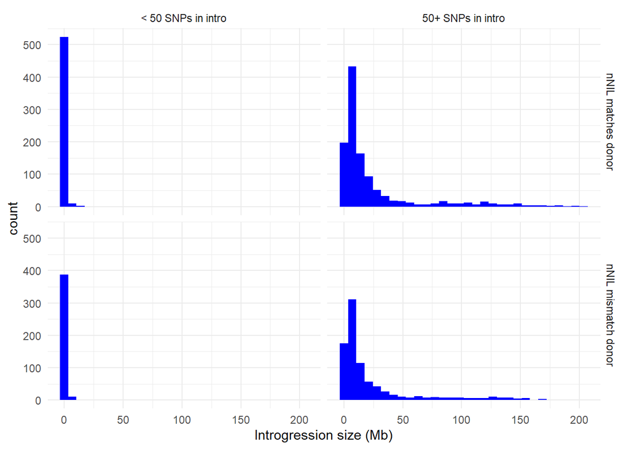

```r
intros.info.for.plots  = intros.info  %>%
  mutate(
         donor_match = ifelse(nNIL_good, "nNIL matches donor", "nNIL mismatch donor"),
         intro_good  = ifelse(intro_good, "50+ SNPs in intro", "< 50 SNPs in intro"))
ggplot(intros.info.for.plots , aes(x = intro.size.Mbp)) +
  geom_histogram(fill = 'blue') +
  facet_grid(rows = vars(donor_match), cols =vars(intro_good))  +
  xlab('Introgression size (Mb)') +
  theme_minimal()
```

The donor match does not seem to affect introgression size distribution much.  
The N.homoz. SNP filter has a big effect, obviously that is picking out introgressions that are either small or not.  
A simpler display is to include all introgressions carried by NILs that match their pedigree donor:

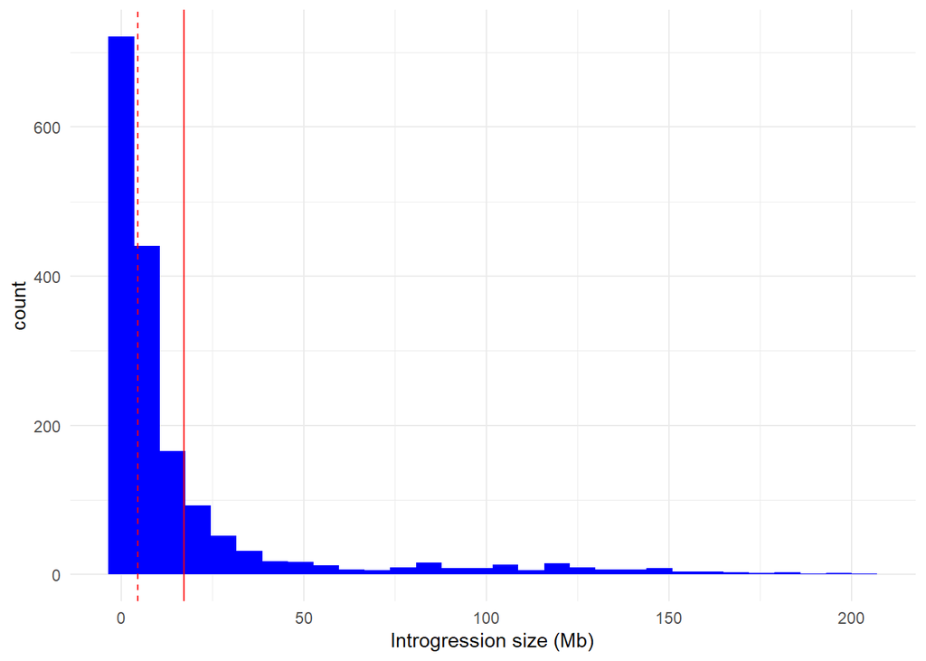

```r
intros.info.for.plots.good.lines = intros.info.for.plots |>
  filter(nNIL_good)

ggplot(intros.info.for.plots.good.lines , aes(x = intro.size.Mbp)) +
  geom_histogram(fill = 'blue') +
  xlab('Introgression size (Mb)') +
  geom_vline(xintercept = mean(intros.info.for.plots.good.lines$intro.size.Mbp), color = "red") +
  geom_vline(xintercept = median(intros.info.for.plots.good.lines$intro.size.Mbp), color = "red", linetype = 2) +
  theme_minimal()
```

```r
#ggsave(filename = "C:/Users/jholland/Box/nNIL genotype data Jim and Tao/Output/Histogram of Introgression Sizes Only Good Founder Matches.tiff", dpi = 300, width = 10, height = 8, units = "in", bg = "white")
```

# Visualize introgression size distributions as proportion of total chromosome lengths

Summary for all introgressions without filtering

```r
summary(intros.info$intro.prop.chr)
```

```
##      Min.   1st Qu.    Median      Mean   3rd Qu.      Max.
## 0.0000001 0.0055100 0.0212658 0.0810901 0.0642727 0.9173837
```

Summary for all introgressions among nNILs with good matches to their pedigree donor

```r
intros.info |>
  filter(nNIL_good) |>
  pull(intro.prop.chr) |>
  summary()
```

```
##      Min.   1st Qu.    Median      Mean   3rd Qu.      Max.
## 0.0000001 0.0050638 0.0221571 0.0816442 0.0660691 0.9001789
```

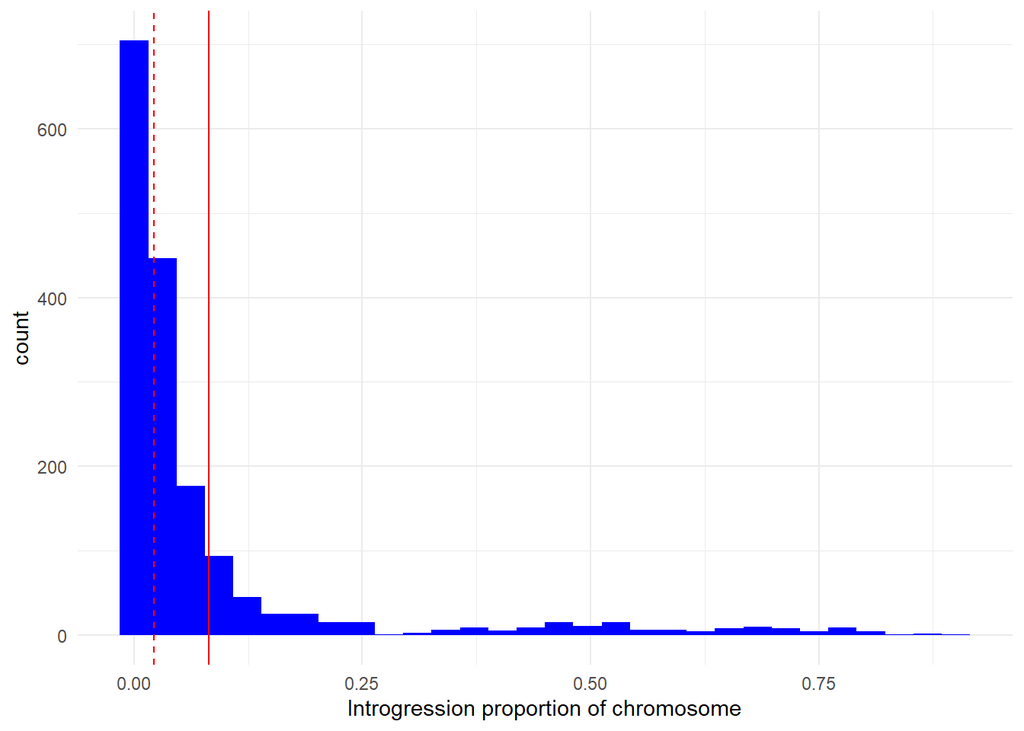

```r
ggplot(intros.info.for.plots.good.lines, aes(x = intro.prop.chr)) +
  geom_histogram(fill = 'blue') +
  geom_vline(xintercept = mean(intros.info.for.plots.good.lines$intro.prop.chr), color = "red") +
  geom_vline(xintercept = median(intros.info.for.plots.good.lines$intro.prop.chr), color = "red", linetype = 2) +
  xlab('Introgression proportion of chromosome') +
  theme_minimal()
```

```r
#ggsave(filename = "C:/Users/jholland/Box/nNIL genotype data Jim and Tao/Output/Histogram of Introgression Proportions of Chromosomes.tiff", dpi = 300, width = 10, height = 8, units = "in", bg = "white")
```

# visualize the proportion of genome introgressed into each nNIL

Re-check the distribution of proportion of genome introgressed, considering only the NILs with Correct Matches to donors

```r
allLines.df  = data.frame(Line = allLines) |>
  separate_wider_delim(cols = Line, delim = "/", names = c("ped.donor2", "suffix"), cols_remove = F) |>
  select(Line, ped.donor2)

line.summary = line.summary %>%
  full_join(mismatch.by.NIL.filtered, by = "Line") |>
  full_join(allLines.df, by = "Line")
line.summary = line.summary |>
  mutate(
    ped.donor = ifelse(is.na(ped.donor), ped.donor2, ped.donor),
    all.intros.match.ped = ifelse(is.na(all.intros.match.ped), F, all.intros.match.ped)) |>#NA values are F
  select(-ped.donor2)

line.summary %>%
  filter(all.intros.match.ped) |>
  pull(Total.Intro.Prop.Unfiltered) |>
  summary()
```

```
##      Min.   1st Qu.    Median      Mean   3rd Qu.      Max.
## 0.0002015 0.0058806 0.0123930 0.0236556 0.0313712 0.1705117
```

Distribution of total proportion of genome introgressed separately for nNILs that match or not their pedigree donor

```r
line.summary %>%
  group_by(all.intros.match.ped) |>
  summarize(mean.intro.rate = mean(Total.Intro.Prop.Unfiltered, na.rm = T),
            N.blocks = mean(N.blocks.unfiltered,na.rm = T))
```

```
## # A tibble: 2 × 3
##   all.intros.match.ped mean.intro.rate N.blocks
##   <lgl>                          <dbl>    <dbl>
## 1 FALSE                         0.0336     4.22
## 2 TRUE                          0.0237     2.93
```

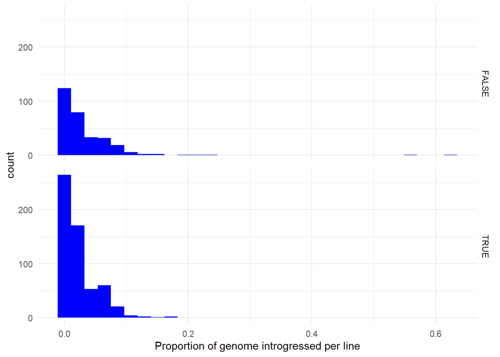

```r
line.summary %>%
  ggplot(aes(x = Total.Intro.Prop.Unfiltered)) +
  geom_histogram(fill = 'blue') +
  facet_grid(rows = vars(all.intros.match.ped)) +
  xlab("Proportion of genome introgressed per line") +
  theme_minimal()
```

Display the distribution only for the nNILs that match their pedigree donor

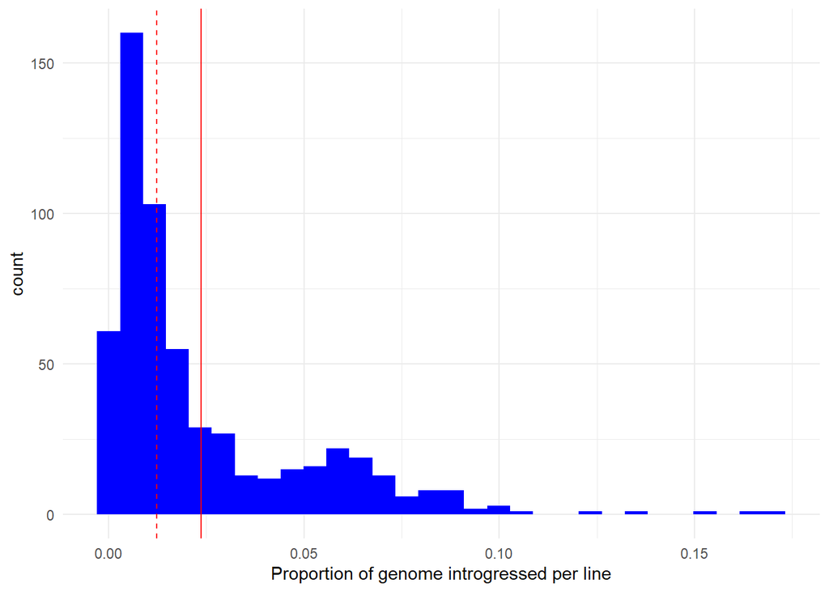

```r
line.summary %>%
  filter(all.intros.match.ped) |>
  ggplot(aes(x = Total.Intro.Prop.Unfiltered)) +
  geom_histogram(fill = 'blue') +
  xlab("Proportion of genome introgressed per line") +
  geom_vline(xintercept = mean(unlist(line.summary[line.summary$all.intros.match.ped,'Total.Intro.Prop.Unfiltered'])), color = "red") +
  geom_vline(xintercept = median(unlist(line.summary[line.summary$all.intros.match.ped,'Total.Intro.Prop.Unfiltered'])), color = "red", linetype = 2) +
  theme_minimal()
```

```r
ggsave(filename = "C:/Users/jholland/Box/nNIL genotype data Jim and Tao/Output/Histogram of Proportion of Whole Genome Introgressed by Line.tiff", dpi = 300, width = 10, height = 8, units = "in", bg = "white")
```

# Summarize the mismatch rates of nNILs according to their pedigree donor

```r
line.summary |>
  group_by(ped.donor) |>
  summarize(prop.mismatch = sum(!all.intros.match.ped)/n(),
            n.mismatch = sum(!all.intros.match.ped),
            n.match = sum(all.intros.match.ped),
            N = n())
```

```
## # A tibble: 18 × 5
##    ped.donor prop.mismatch n.mismatch n.match     N
##    <chr>             <dbl>      <int>   <int> <int>
##  1 CML103            0.495         47      48    95
##  2 CML228            0.405         17      25    42
##  3 CML247            0.186          8      35    43
##  4 CML277            0.304         14      32    46
##  5 CML322            0.244         11      34    45
##  6 CML333            0.189         14      60    74
##  7 CML52             0.737         42      15    57
##  8 CML69             0.312         15      33    48
##  9 Ki11              0.182          8      36    44
## 10 Ki3               0.517         15      14    29
## 11 M162W             0              0      18    18
## 12 Mo17              0.185          5      22    27
## 13 Mo18W             0.147         11      64    75
## 14 NC350             0.386         17      27    44
## 15 NC358             0.474         18      20    38
## 16 Oh43              0.542         32      27    59
## 17 Tx303             0.447         21      26    47
## 18 Tzi8              0.263         15      42    57
```

# Save introgression details and match information to files

Save files with details of individual introgressions and their match probabilities before filtering

```r
write.csv(intros.info, file = paste0(base.path, "nNIL_data_supplement/File_S05.Individual_Introgressions_gbs_donor_matches.csv"), row.names = F, quote = F)
```

Save the file with details of line introgression donor matches for all lines based on introgressions filtered for N.homoz

```r
line.summary = line.summary |>
  select(Line, ped.donor, best.matches, all.intros.match.ped, N.blocks.unfiltered, Total.Intro.Sizes.Unfiltered, Total.Intro.Prop.Unfiltered, N.blocks.filtered, N.mismatch.blocks, N.NA.blocks, N.donor.matches)
write.csv(line.summary, file = paste0(base.path, "nNIL_data_supplement/File_S06.nNIL_intro_and_donor_match_summary.csv"), row.names = F, quote = F)
```

# Distribution of introgression rates by marker

Convert the 0,1,2 introgression dosage calls to 0,1 where 1 is either het or homozygous for the introgression.  
This is so that we measure introgression blocks at their maximum size (if it’s homoz in one section but continues at het at another section, we will measure the longest contiguous introgression block length.) If you don’t do this, then there will be complications with measuring nested introgressions (a homozygous block inside a het block.).  
Drop first column, which are the line names

```r
intros01 = intro.calls[,!1, with = F]
intros01[intros01 > 0] = 1
```

Merge the original introgression calls (1 score means either het or homozygous) with the founder information and map the introgression coverage over the genome

```r
setDF(intros01) #convert from data.table to data.frame
intros01 = intros01 |>
  mutate(Line = unlist(intro.calls[,1]))
intros01.founders = merge(line.summary, intros01, by = "Line")
```

Compute the number of nNILs with an introgression for each marker. First 11 columns of intros01.founders are meta-data, skip these when computing.

```r
intro.coverage.by.marker = apply(intros01.founders[,-c(1:11)], 2, sum)
summary(intro.coverage.by.marker)
```

```
##    Min. 1st Qu.  Median    Mean 3rd Qu.    Max.
##    5.00   19.00   24.00   24.23   29.00   45.00
```

Summarize the introgression coverage as max number of nNILs with an introgression within 1 Mbp bins

```r
intro.coverage.by.marker.df = data.frame(Marker = colnames(intros01.founders)[-c(1:11)], coverage = intro.coverage.by.marker) |>
  separate(Marker, into = c("Chr", "Pos"), sep = "_", remove = F) |>
  mutate(Chr = as.numeric(sub("S", "", Chr)),
         Pos = as.numeric(Pos),
         Mbp = Pos/1000000)

intro.coverage.by.bin = intro.coverage.by.marker.df |>
  mutate(bin = round(Mbp, digits = 0)) |>
  group_by(Chr, bin) |>
  summarize(MaxCoverage = max(coverage, na.rm = T))
```

[output not shown]

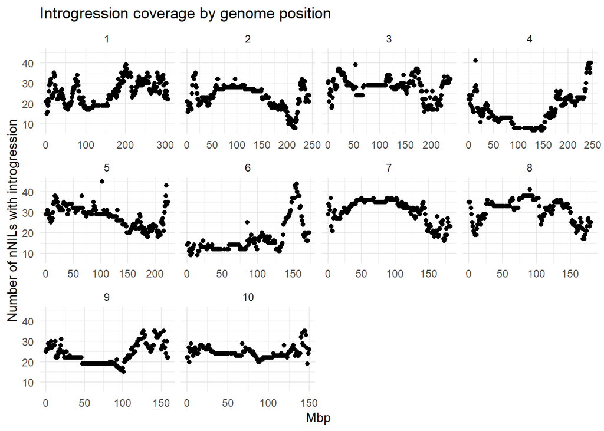

```r
intro.coverage.plot = ggplot(intro.coverage.by.bin , aes(x = bin, y = MaxCoverage)) +
  geom_point() +
  facet_wrap(facets = vars(Chr), scales = "free_x") +
  xlab("Mbp") +
  ylab("Number of nNILs with introgression") +
  ggtitle("Introgression coverage by genome position") +
  theme_minimal()

intro.coverage.plot
```

Compare introgression coverage using all nNILs vs using only subset of nNILs with correct donor matches

```r
intro.coverage.by.marker.good.lines = apply(intros01.founders[intros01.founders$all.intros.match.ped,-c(1:11)], 2, sum)
summary(intro.coverage.by.marker.good.lines)
```

```
##    Min. 1st Qu.  Median    Mean 3rd Qu.    Max.
##    0.00   11.00   14.00   13.91   17.00   30.00
```

```r
intro.coverage.by.marker.good.lines.df = data.frame(Marker = colnames(intros01.founders)[-c(1:11)], coverage = intro.coverage.by.marker.good.lines) |>
  separate(Marker, into = c("Chr", "Pos"), sep = "_", remove = F) |>
  mutate(Chr = as.numeric(sub("S", "", Chr)),
         Pos = as.numeric(Pos),
         Mbp = Pos/1000000)

intro.coverage.by.bin.good.lines = intro.coverage.by.marker.good.lines.df |>
  mutate(bin = round(Mbp, digits = 0)) |>
  group_by(Chr, bin) |>
  summarize(MaxCoverage = max(coverage, na.rm = T))
```

[output not shown]

Plot marker coverage for both all nNILs and only good founder match nNILs on same plot

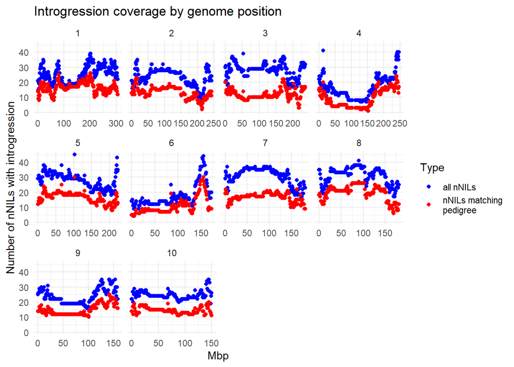

```r
intro.coverage.by.bin$Type = "all nNILs"
intro.coverage.by.bin.good.lines$Type = "nNILs matching\npedigree"
intro.coverage.both = bind_rows(intro.coverage.by.bin, intro.coverage.by.bin.good.lines)


intro.coverage.plot.both = ggplot(intro.coverage.both , aes(x = bin, y = MaxCoverage)) +
  geom_point(aes(colour = Type)) +
  facet_wrap(facets = vars(Chr), scales = "free_x") +
  xlab("Mbp") +
  ylab("Number of nNILs with introgression") +
  ggtitle("Introgression coverage by genome position") +
  scale_colour_manual(values = c("blue", "red")) +
  theme_minimal()

intro.coverage.plot.both
```

```r
ggsave(intro.coverage.plot.both,filename = "C:/Users/jholland/Box/nNIL genotype data Jim and Tao/Output/Introgression coverage by genome position.tiff", dpi = 300, width = 10, height = 8, units = "in", bg = "white")
```